# ΜΙΣΤΑ002: Two-sample t-test (Student’s t-test)

## Two-sample t-test (Student’s t-test)

Two sample t-test can be used if we have two independent (unrelated) groups eg. males-females, unmatched case-controls, treatment-non treatment and one quantitative variable of interest. For example, we may wish to compare the age in males and females or the weights in two groups of children, each child being randomly allocated to receive either a dietary supplement or placebo.

**Assumptions**

- in the population, the variable is normally distributed in each group (if total sample size less than 25 otherwise this is less important)
- the underlying variances in the two groups are similar

**Notation**

**Steps for conducting the test**

**Step 1. Define the null and alternative hypotheses under study**

**H<sub>0</sub>**: the population means in the two groups are equal (μ<sub>1</sub>=μ<sub>2</sub>).

**H<sub>1</sub>**: the population means in the two groups are not equal (μ<sub>1</sub>≠μ<sub>2</sub>).

Under the null hypothesis, the t statistic follows the t-distribution with n<sub>1</sub>+n<sub>2</sub>-2 degrees of freedom (d.f.) .

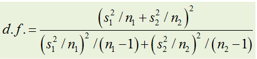

**Step 3. Calculate the p value from the t-distribution**

The corresponding p-value for the t statistic can be calculated as the cumulative probability Pr(T>|t|) for a variable T that follows a t distribution with n<sub>1</sub>+n<sub>2</sub>-2 degrees of freedom. H<sub>0</sub> is rejected if the p-value is less than the significance level alpha (e.g. 0.05).

An old fashioned way for testing H<sub>0</sub> would be to compare the calculated t statistic with the corresponding critical value at level α of the t distribution. This is rarely used in the computers era, if ever.

In practice, after calculating the t statistic, one may resort to online calculators of the t-distribution (e.g. http://stattrek.com/online-calculator/t-distribution.aspx) in order to get the cumulative probability that T<t. Then, the p-value is 2*(1-Pr(T<t)). Statistical software (e.g. R, SPSS) automatically provide the p-value.

**Step 4. Calculate the Confidence Interval (CI)**

The (1-a)% confidence interval for the difference of the two means at significance level alpha, with d.f. degrees of freedom and for a two-tailed t-test is given by

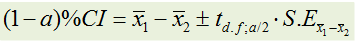

Note that, if the means are significantly different, the (1-a)%CI of the difference will not include zero.

**Step 5. Interpretation**

Interpretation of the results.

**Worked Example**

[figure not shown]

Blood pressure levels were measured in 100 diabetic and 100 non-diabetic men aged 40-49 years. Mean systolic blood pressure was 146.4 mmHg with standard deviation 18.5 mmHg among the diabetics and 140.4 mmHg with standard deviation 16.8 mmHg among the non-diabetics. Supposed that the assumptions of Normality and constant variance are satisfied, perform a two-tailed two-sample t-test to compare the means in the two groups (a=0.05) (example from Altman, 2000).

**Step 1. Define the null and alternative hypotheses under study**

**H<sub>0</sub>**: the population means of systolic blood pressure in the two groups are equal (μ<sub>1</sub>=μ<sub>2</sub>).

**H<sub>1</sub>**: the population means of systolic blood pressure in the two groups are not equal (μ<sub>1</sub>≠μ<sub>2</sub>).

**Step 2. Calculate the value of the test statistic specific to H<sub>0</sub>**

We calculate the pooled standard deviation of the two groups:

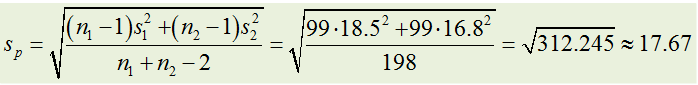

and the test statistic t is

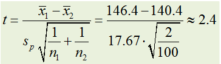

The t statistic follows the t-distribution with 198 degrees of freedom.

**Step 3. **Calculate the p value from the t-distribution****

From an online calculator we get Pr(T<2.4)=0.9913. Then, the p-value is 2*(1-0.9913)=0.0174 < 0.05.

**Step 4. Calculate the Confidence Interval (CI)**

Therefore, the 95% confidence interval for the true difference in the two means ranges from 1.1mmHg to 10.9mmHg . Note that the zero is not included in the 95%CI of the difference.

________________________________________

Altman, D., Machin, D., Bryant, T., Gardner, M. (2000). *Statistics with Confidence: Confidence Intervals and Statistical Guidelines* (2<sup>nd</sup> Ed.) . BMJ Books.

Last modified: Wednesday, 13 February 2019, 7:58 PM